# Milestone Report: Predictive Word Algorithm

Victor Lacerda

7/8/2020

## Introduction

The aim of this project is to create a predictive word algorithm and deploy this into a ShinyApp. The [dataset](https://d396qusza40orc.cloudfront.net/dsscapstone/dataset/Coursera-SwiftKey.zip) was provided by SwiftKey in cooperation with Johns Hopkins University on Coursera and consists of Twitter, Blogs, and News extracts in English, German, Finish and Russian.

## Libraries Used

```r
library(stringr); library(tm); library(dplyr); library(tibble); library(reshape); library(RWeka); library(LaF); library(purrr); library(tidyr)
library(ggplot2); library(data.table); library(tidytext)
```

## Data Processing

### 1. Importing Data

```r
if (! file.exists("Coursera-SwiftKey.zip")) {
        download.file("https://d396qusza40orc.cloudfront.net/dsscapstone/dataset/Coursera-SwiftKey.zip", "Coursera-SwiftKey.zip", mode = "wb")
        unzip("Coursera-SwiftKey.zip")
}

files <- list.files(pattern = "en_US", recursive = T)

set.seed(133)
for (i in 1:length(files)) {
        assign(files[i], sample_lines(files[i], 500))
}

dat_all <- c(mget(unlist(files)))

rm(list = files)
```

During the import we also sample the files by use of *sample_lines*

### 2. Cleaning & Sampling Data

```r
dat_all <- dat_all %>%
        map(., as.data.frame) %>%
        rbindlist(., fill = T, idcol = T) %>%
        dplyr::rename(., doc_id = .id, text = `.x[[i]]`) %>%
        mutate(., doc_id = as.factor(sub(".*\\_ *(.*?) *.txt*", "\\1", doc_id)))

# Training and Test Data

training <- dat_all %>%
        sample_frac(., 0.75) %>%
        data.frame(.)

test <- dat_all %>%
        sample_frac(., 0.25) %>%
        data.frame(.)

rm(dat_all)

# N-gram and Corpus

token <- function(x) {
        NGramTokenizer(x, Weka_control(min = 1, max = 4))
}

training <- training %>%
        as.data.frame(.) %>%
        DataframeSource(.) %>%
        VCorpus(., readerControl = list(language = "en")) %>%
        tm_map(., content_transformer(tolower)) %>%
        tm_map(., content_transformer(removeNumbers)) %>%
        tm_map(., content_transformer(stripWhitespace)) %>%
        tm_map(., content_transformer(function(.) gsub("[^\x01-\x7F]+", "", .))) %>%
        tm_map(., content_transformer(function(.) removePunctuation(., preserve_intra_word_contractions = T, preserve_intra_word_dashes = T)))%>%
        #tm_map(., removeWords, stopwords(kind = "en")) %>%
        #tm_map(., stemDocument, "en") %>%
        tm_map(., content_transformer(PlainTextDocument)) %>%
        DocumentTermMatrix(., control = list(tokenize = token))%>%
        as.matrix(.) %>%
        as.data.frame(.) %>%
        gather(., Word, Frequency, names(.)) %>%
        group_by(., Word) %>%
        summarise(., Frequency = sum(Frequency)) %>%
        ungroup(.) %>%
        mutate(., N_gram = str_count(Word, "\\S+")) %>%
        group_by(., N_gram) %>%
        mutate(., Prop = Frequency/ sum(Frequency),
               Word_to_Predict = word(Word, -1)) %>%
        data.frame(.)

head(training)
```

```
##             Word Frequency N_gram         Prop Word_to_Predict
## 1          a bad         1      2 3.043306e-05             bad
## 2     a bad joke         1      3 3.149904e-05            joke
## 3 a bad joke but         1      4 3.262536e-05             but
## 4         a ball         2      2 6.086612e-05            ball
## 5      a ball of         1      3 3.149904e-05              of
## 6  a ball of wax         1      4 3.262536e-05             wax
```

During the cleaning we perform the following text-manipulations:

- Lowercase
- Remove punctuations
- Remove numbers
- Stripe white spaces
- Remove non-ASCII characters

Additional steps that I could have taken include:

- Remove stopwords in the texts language to avoid predicting words like: “the”, “it”, “and” etc.
- Stem the data to reduce words to unify accross sentences.
- Remove sparse words (words with low frequency) from the data as they won’t play a high importance in the algorithm.

Since stop words are key words in the language excluding them wouldn’t provide a very usefull prediction algorithm. While stemming the data is useful to create n-grams it provides to be a challenge in using stem words to predict a next word. Lastly, sparse words were kept to provide a more complete dictionary.

### 3. Exploratory Analysis

```r
top.plot <- training %>%
        group_by(., N_gram) %>%
        top_n(., 10, Prop) %>%
        ggplot(., aes(x = reorder_within(Word_to_Predict, -Prop, N_gram), y = Prop, fill = as.factor(N_gram))) +
        geom_bar(stat="identity", position="dodge") + facet_wrap(~ N_gram, ncol = 2, scales = "free") +
        scale_y_continuous(labels = scales::percent) + theme_bw() + scale_x_reordered() +
        labs(title = "Top Predicted Words by N-gram", x = "Words", fill = "N-gram") +
        coord_flip()
```

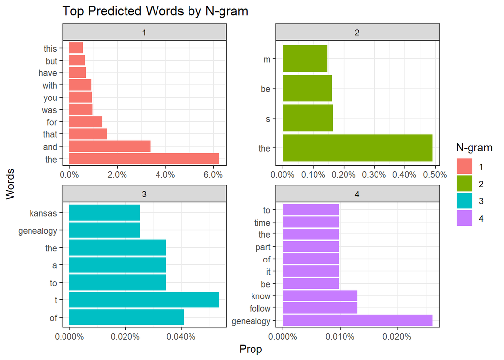

```r
top.plot
```

### 4. Model

The model used to predict the next word make use of the N_grams created. Quite simply if the user enters a word of length n, the NextWordPrediction function looks for words in the (n+1)-gram that matches those inputs and returns the last word in the n-gram with the highest occurance. To enable learning, once a input is called we update proportions accordingly. If no matches are found, the function tries matching with n-first word until n = 1. If no matches are found we add this to the dataset.

E.g: Input = “she was” n = 2 The NextWordPrediction function looks for words in the 3-gram (n+1) that matches those inputs and returns the last word in the 3-gram with the highest occurance and update proportions of input accordingly. If no matches are found, the function tries matching with input = “was”. If no matches are found we add this to the dataset.

```r
NextWordPrediction <- function(input) {
        dat <- training %>%
                filter(., N_gram == str_count(input, "\\S+") + 1) %>%
                filter(grepl(paste("^", tolower(str_squish(input)), "\\b", sep = ""), Word)) %>%
                arrange(., desc(Prop))

        if (nrow(dat) != 0) {
                assign("training",
                       training %>%
                               mutate(Frequency = ifelse(Word == input &
                                                                 N_gram == str_count(input, "\\S+"),
                                                         Frequency + 1,
                                                         Frequency)) %>%
                               group_by(., N_gram) %>%
                               mutate(., Prop = Frequency/ sum(Frequency)) %>%
                               data.frame(.),
                       envir = .GlobalEnv)

                val <- dat$Word_to_Predict[1]
                ans <- paste(str_squish(input), val)

                return(list(ans, head(dat,5)))

        } else {
                for (i in 2:str_count(input, "\\S+")) {
                        input_1 <-  word(input, start = i, end =  str_count(input,"\\S+"))

                        dat <- training %>%
                                filter(., N_gram == str_count(input_1, "\\S+") + 1) %>%
                                filter(grepl(paste("^", tolower(str_squish(input_1)), "\\b", sep = ""), Word)) %>%
                                arrange(., desc(Prop))
                        if (nrow(dat) != 0) {
                                val <- dat$Word_to_Predict[1]
                                ans <- paste(str_squish(input), val)

                                return(list(ans, head(dat,5)))

                        } else if (nrow(dat) == 0 & i == str_count(input, "\\S+")) {

                                for (i in str_count(input, "\\S+"):1) {
                                        input_1 <-  word(input, start = 1, end =  i)

                                        assign("training",
                                               training %>%
                                                       add_row(., Word = tolower(input_1), Frequency = + 1, N_gram = str_count(input_1, "\\S+"),
                                                               Word_to_Predict = word(input_1, -1)) %>%
                                                       group_by(., N_gram) %>%
                                                       mutate(., Prop = Frequency/ sum(Frequency)) %>%
                                                       data.frame(.),
                                               envir = .GlobalEnv)
                                }

                                ans <- paste("Word not in dictionary. We added this to our database!")

                                return(ans)
                        }
                }
        }
}
```

### 4. Model Evaluation

As an attempt to evaluate the model I propose applying the NextWordPrediction function to predict the test set. Since the creation of N-grams in the test set creates all possible combinations of words that arises from the test set, we can apply the NextWordPrediction function to all but the last word in n-gram and compare the original n-gram to the resulting answer from NextWordPrediction. This evaluation yields an accuracy of 47%.

```r
test <- test %>%
        as.data.frame(.) %>%
        DataframeSource(.) %>%
        VCorpus(., readerControl = list(language = "en")) %>%
        tm_map(., content_transformer(tolower)) %>%
        tm_map(., content_transformer(removeNumbers)) %>%
        tm_map(., content_transformer(stripWhitespace)) %>%
        tm_map(., content_transformer(function(.) gsub("[^\x01-\x7F]+", "", .))) %>%
        tm_map(., content_transformer(function(.) removePunctuation(., preserve_intra_word_contractions = T, preserve_intra_word_dashes = T)))%>%
        tm_map(., content_transformer(PlainTextDocument)) %>%
        DocumentTermMatrix(., control = list(tokenize = token))%>%
        as.matrix(.) %>%
        as.data.frame(.) %>%
        gather(., Word, Frequency, names(.)) %>%
        group_by(., Word) %>%
        summarise(., Frequency = sum(Frequency)) %>%
        ungroup(.) %>%
        mutate(., N_gram = str_count(Word, "\\S+")) %>%
        group_by(., N_gram) %>%
        mutate(., Prop = Frequency/ sum(Frequency)) %>%
        data.frame(.)

test$test <- 1
for (i in 1:nrow(test)) {
        # print(i) run as progress bar
        word <- ifelse(test[i,3] == 1, test[i,1], word(test[i,1], start = 1, end = str_count(test[i,1],"\\S+")-1))
        test[i,5] <- NextWordPrediction(word)[1]
}

check <- test %>%
        mutate(., check = ifelse(Word == test, 1, 0)) %>%
        summarise(., Accuracy = sum(check)/nrow(.))
check
```

```
##    Accuracy
## 1 0.4696159
```